# Midterm

#### 2. Do planes trade ownership?

You might expect that there’s an implicit relationship between plane and airline, because each plane is flown by a single airline. Explore this conjecture using data. (Let’s assume that the tail number of a plane does not change.)

If we assume that each tail number doesn’t change, we see there are 18 tail numbers that appear under more than one airline. This demonstrates that planes can trade ownership and be sold to other airlines, although it isn’t super common.

```r
tailnum_by_airline = flights %>%
  group_by(tailnum, carrier) %>%
  summarise(n =n())

tailnum_count = tailnum_by_airline %>% count(tailnum)

sum(tailnum_count$n > 1)
```

```
## [1] 18
```

#### 3a. Plane’s average speed

Notice that `flights$air_time` is in minutes. Make a new column that is the air time in hours.

```r
flights = flights %>% mutate(air_hour = (air_time /60))
```

#### 3b. Average speed

For each flight, compute the average speed of that flight (in miles per hour).  
Then, for each plane, compute the average of those average speeds. Display it in a histogram. You can use a base R histogram `hist` or ggplot’s `geom_histogram`.

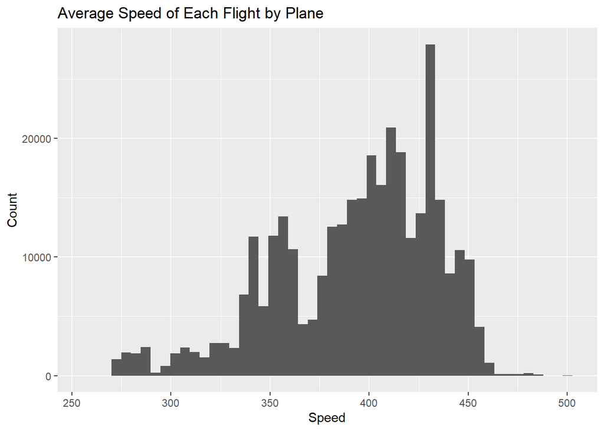

```r
flights %>%
  group_by(flight) %>%
  mutate(speed1 = distance/air_hour) %>%
  group_by(tailnum) %>%
  mutate(speed2 = mean(speed1, na.rm = T)) %>%
  ggplot(aes(speed2)) +
  geom_histogram(bins = 50) +
  labs(title = "Average Speed of Each Flight by Plane", x = "Speed", y = "Count")
```

#### 4. Bonus

Make a table where each row is a destination, each column is a carrier, and each element is the number of times that the carrier has flown to that destination. Ensure that you only count flights that arrived at the destination.

```r
flights %>%
  group_by(dest, carrier) %>%
  summarise(count = n())  %>%
  pivot_wider(names_from = carrier, values_from = count)
```

```
## # A tibble: 105 x 17
## # Groups:   dest [105]
##    dest     B6    EV    UA  `9E`    DL    FL    MQ    WN    AA    US    OO    YV
##    <chr> <int> <int> <int> <int> <int> <int> <int> <int> <int> <int> <int> <int>
##  1 ABQ     254    NA    NA    NA    NA    NA    NA    NA    NA    NA    NA    NA
##  2 ACK     265    NA    NA    NA    NA    NA    NA    NA    NA    NA    NA    NA
##  3 ALB      NA   439    NA    NA    NA    NA    NA    NA    NA    NA    NA    NA
##  4 ANC      NA    NA     8    NA    NA    NA    NA    NA    NA    NA    NA    NA
##  5 ATL      NA  1764   103    59 10571  2337  2322    59    NA    NA    NA    NA
##  6 AUS     747    NA   670     2   357    NA    NA   298   365    NA    NA    NA
##  7 AVL      NA   265    NA    10    NA    NA    NA    NA    NA    NA    NA    NA
##  8 BDL      NA   435     8    NA    NA    NA    NA    NA    NA    NA    NA    NA
##  9 BGR      NA   374    NA     1    NA    NA    NA    NA    NA    NA    NA    NA
## 10 BHM      NA   297    NA    NA    NA    NA    NA    NA    NA    NA    NA    NA
## # ... with 95 more rows, and 4 more variables: F9 <int>, HA <int>, VX <int>,
## #   AS <int>
```